# Homework_10

Joe Webb

3/30/2022

Return to Homepage

# For Loops and Randomized Tests

In this lab, students will create their own `for` loops to calculate a variety of statistics as prompted.

## Question 1

Using a `for` loop, write a function to calculate the number of zeroes in a numeric vector. Before entering the loop, set up a counter variable `counter <- 0`. Inside the loop, add `1` to `counter` each time you have a zero in the matrix. Finally, use `return(counter)` for the output.

```r
##################################################
# FUNCTION: count_zeroes()
# Determines the number of zeroes in a numeric vector
# input: x = name of numeric vector in question
# output: counter = number of zeroes in vector
#-------------------------------------------------
# Global variables
counter <- 0
sim.vec <- c(0,0,1,2,3,4)
#-------------------------------------------------
# Function
count_zeroes <- function(x=sim.vec) {
  for(i in 1:length(sim.vec)) {
   if(x[i] == 0) {
        counter <- counter+1
   } # end of if
   else {
        next
   } # end of else
  } #end of for loop
  print(counter)
} # end of function

#-------------------------------------------------
# Example
samplevec <- c(0,0,0,1,2,3,4,5,6)
count_zeroes(x=samplevec)
```

[output not shown]

## Question 2

Use subsetting instead of a loop to rewrite the function as a single line of code.

```r
howmany_zeroes <- length(subset(samplevec, samplevec==0))
print(howmany_zeroes)
```

```
## [1] 3
```

## Question 3

Write a function that takes as input two integers representing the number of rows and columns in a matrix. The output is a matrix of these dimensions in which each element is the product of the row number x the column number.

```r
##################################################
# FUNCTION: multip_table()
# Multiples column number by row number in each cell
# input: nrow = number of rows
#        ncol = number of columns
# output: matrix of these dimensions, each cell product of input values
#-------------------------------------------------
# Function body
multip_table <- function(nrow=10,ncol=10) {
                  seq.int(nrow) %o%
                  seq.int(ncol)
}
#-------------------------------------------------
# Example
multip_table(nrow=8,ncol=8)
```

```
##      [,1] [,2] [,3] [,4] [,5] [,6] [,7] [,8]
## [1,]    1    2    3    4    5    6    7    8
## [2,]    2    4    6    8   10   12   14   16
## [3,]    3    6    9   12   15   18   21   24
## [4,]    4    8   12   16   20   24   28   32
## [5,]    5   10   15   20   25   30   35   40
## [6,]    6   12   18   24   30   36   42   48
## [7,]    7   14   21   28   35   42   49   56
## [8,]    8   16   24   32   40   48   56   64
```

## Question 4 (Prior to Randomization Tests Lecture)

### Question 4a

Simulate a dataset with 3 groups of data, each group drawn from a distribution with a different mean. The final data frame should have 1 column for group and 1 column for the response variable.

```r
# respoonse variables
mean1 <- 5
mean2 <- 10
mean3 <- 15
# Label groups of data
group1 <-rnorm(n=10,mean=mean1)
group2 <-rnorm(n=10,mean=mean2)
group3 <-rnorm(n=10,mean=mean3)

#Create data frame
groupnames <- c("A","B","C")
response_variables <- c(group1,group2,group3)

sim_dataset <- cbind(groupnames,response_variables)
print(sim_dataset)
```

[output not shown]

[output cut: 16 more lines]

### Question 4b

Write a custom function that 1) reshuffles the response variable, and 2) calculates the mean of each group in the reshuffled data. Store the means in a vector of length 3.

```r
##################################################
# FUNCTION: shuffle_matrix()
# Shuffles the inital mean values and prints the resulting matrix
# input: mean1 = the mean of the first value
#        mean2 = the mean of the second value
#        mean3 = the mean of the third value
# output: the corresponding matrix and vector of the means selected
#-------------------------------------------------
# Function body

shuffle_matrix <- function(mean1=5,mean2=10,mean3=15) {
                  myvec <- c(mean1,mean2,mean3)
                  groupnames <- c("A","B","C")
                  group1 <-rnorm(n=10,mean=mean1)
                  group2 <-rnorm(n=10,mean=mean2)
                  group3 <-rnorm(n=10,mean=mean3)

                  response_variables <- c(group1,group2,group3)

                  sim_dataset <- cbind(groupnames, response_variables)
                  print(sim_dataset)
                  print(myvec)
}
#-------------------------------------------------
# Example
shuffle_matrix(mean1=10,mean2=20,mean3=30)
```

```
##       groupnames response_variables
##  [1,] "A"        "9.73603127294143"
##  [2,] "B"        "8.02235393824823"
##  [3,] "C"        "10.7693198041109"
##  [4,] "A"        "10.599732175664"
##  [5,] "B"        "8.82239978863955"
##  [6,] "C"        "11.4724242482406"
##  [7,] "A"        "10.1564926968778"
##  [8,] "B"        "9.42432740291131"
##  [9,] "C"        "9.65565469461725"
## [10,] "A"        "9.91176033700969"
## [11,] "B"        "20.5156622811596"
## [12,] "C"        "21.5194126556155"
## [13,] "A"        "21.0112335912651"
## [14,] "B"        "19.6218522821895"
```

[output cut: 17 more lines]

### Question 4c

Use a for loop to repeat the function in b 100 times. Store the results in a data frame that has 1 column indicating the replicate number and 1 column for each new group mean, for a total of 4 columns.

```r
library(dplyr)
library(tidyr)

results <- data.frame()

for(i in 1:100){
  shuffle <- sample(1:nrow(sim_dataset), replace=FALSE)
    data_frame_shuffle <- data.frame(groupnames, shuffle)
  sum_mean <- data_frame_shuffle %>% group_by(groupnames) %>%
    summarise(mean = mean(shuffle))
  df1 <- sum_mean %>% pivot_wider(names_from = groupnames, values_from = mean)
  final_df <- cbind(i, df1)

  results <- rbind(results, final_df)
}

print(results)
```

```
##       i    A    B    C
## 1     1 12.4 16.6 17.5
## 2     2 13.3 17.5 15.7
## 3     3 14.5 19.2 12.8
## 4     4  8.3 18.1 20.1
## 5     5 14.1 16.3 16.1
## 6     6 18.9 15.3 12.3
## 7     7 13.7 16.7 16.1
## 8     8 12.5 16.3 17.7
## 9     9 19.4 12.4 14.7
## 10   10 16.6 11.8 18.1
## 11   11 16.4 17.5 12.6
## 12   12 14.0 15.3 17.2
## 13   13 13.1 15.8 17.6
## 14   14 14.0 15.2 17.3
```

[output cut: 86 more lines]

### Question 4d

Use qplot() to create a histogram of the means for each reshuffled group. Or, if you want a challenge, use ggplot() to overlay all 3 histograms in the same figure. How do the distributions of reshuffled means compare to the original means?

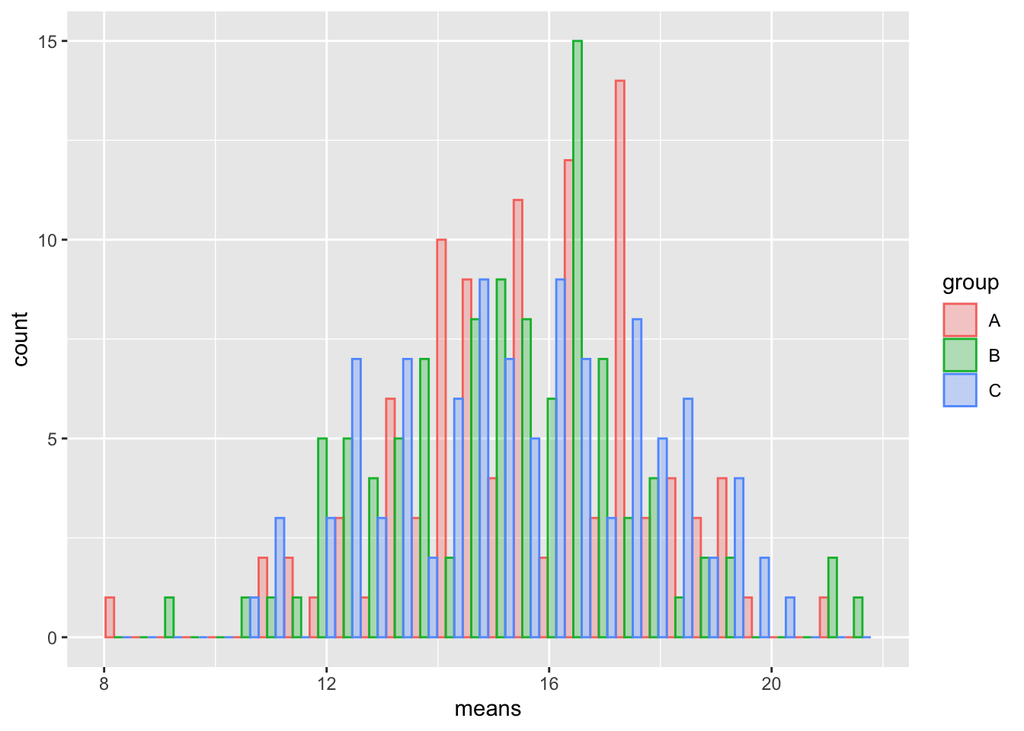

```r
longdf <- results %>%
  pivot_longer(cols = 2:4,
               names_to = "group",
               values_to = "means")

# head(longdf)

ggplot(data = longdf,
       aes(x = means, fill = group, color = group)) +
       geom_histogram(position = "dodge", alpha = 0.3)
```

## Question 4 (After Randomization Lecture)

Use the code from the upcoming April 2nd lecture (Randomization Tests) to design and conduct a randomization test for some of your own data. You will need to modify the functions that read in the data, calculate the metric, and randomize the data. Once those are set up, the program should run correctly calling your new functions. Also, to make your analysis fully repeatable, make sure you set the random number seed at the beginning (use either `set.seed()` in base R, or `char2seed` in the `TeachingDemos` package

```r
# The following function has been retrieved from Nicholas Gotelli's Bio381 Randomization Tests Lecture.

# FUNCTION read_data
# description: read in (or generate) data set for analysis
# inputs: file name (or nothing, as in this demo)
# outputs: 3 column data frame of observe data (ID, x, y)
##########################################
read_data <- function(z=NULL) {
          if(is.null(z)) {
                x_obs <- 1:20
                y_obs <- x_obs + 10*rnorm(20)
                df <- data.frame(ID=seq_along(x_obs),
                                 x_obs,
                                 y_obs)}

          return(df)
} # end of read_data
# -------------------------------
# -------------------------------
# FUNCTION get_metric
# description: calculate metric for randomization test
# inputs: 2-column data frame for regression
# outputs: regression slope
##########################################
get_metric <- function(z=NULL) {
        if(is.null(z)){
          x_obs <- 1:20
          y_obs <- x_obs +10*rnorm(20)
          z <- data.frame(ID=seq_along(x_obs),
                          x_obs,
                          y_obs)}
        . <- lm(z[,3]~z[,2])
        . <- summary(.)
        . <- .$coefficients[2,1]
        slope <- .

        return(slope)

}
# -------------------------------
# -------------------------------
# FUNCTION shuffle_data
# description: randomize data foor regression analysis
# inputs: 3 column data frame (ID, xvar, yvar)
# outputs: 3 column data frame (ID, xvar, yvar)
##########################################
shuffle_data <- function(z=NULL) {
                if(is.null(z)){
                    x_obs <- 1:20
                    y_obs <- x_obs + 10*rnorm(20)
                    z <- data.frame(ID=seq_along(x_obs),
                                    x_obs,
                                    y_obs)}
                z[,3] <- sample(z[,3])

return(z)
}
# -------------------------------
# -------------------------------
# FUNCTION get_pval
# description: calculate p value from simulation
# inputs: list of observed metric and vector of simulated metrics
# outputs: lower and upper tail probability value
##########################################
get_pval <- function(z=NULL) {
          if(is.null(z)){
              z <- list(rnorm(1),rnorm(1000)) }
          p_lower <- mean(z[[2]]<=z[[1]])
          p_upper <- mean(z[[2]]>=z[[1]])

          return(c(pL=p_lower,pU=p_upper))
          }
#---------------------------------------
# -------------------------------
# FUNCTION plot_ran_test
# description: create a ggplot of histogram of simulated values
# inputs: list of observed metric and vector of simulated metrics
# outputs: saved ggplot graph
##########################################
plot_ran_test <- function(z=NULL) {
            if(is.null(z)) {
                  z <- list(rnorm(1),rnorm(1000)) }
            df <- data.frame(ID=seq_along(z[[2]]), sim_x=z[[2]])
            p1 <- ggplot(data=df, mapping=aes(x=sim_x))
            p1 + geom_histogram(mapping=aes(fill=I("goldenrod"),
                                            color=I("black"))) +
              geom_vline(aes(xintercept=z[[1]],col="blue"))

            }
#--------------------------------
#############################################
```

```r
## Apply Randomization Functions
sim_length <- 1000
sim_vector <- rep(NA,sim_length)
df <- read_data() # retrieve simulated data
x_obs <- get_metric(df) #get slope of observed data

for (i in seq_len(sim_length)) {
  sim_vector[i] <- get_metric(shuffle_data(df))
}

slopes <- list(x_obs,sim_vector)
get_pval(slopes)
```

```
## pL pU
##  1  0
```

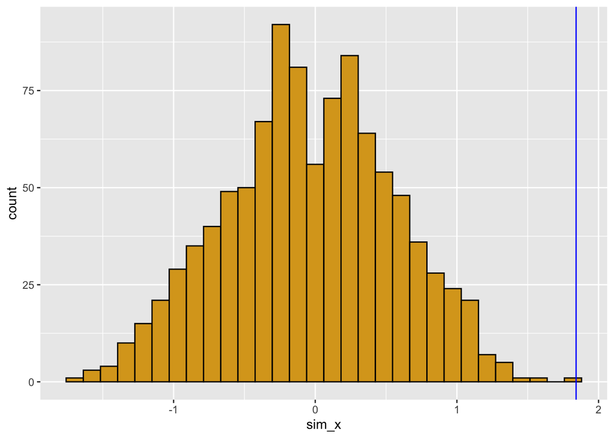

```r
plot_ran_test(slopes)
```